# Or & Amit- Coffee Data Analysis

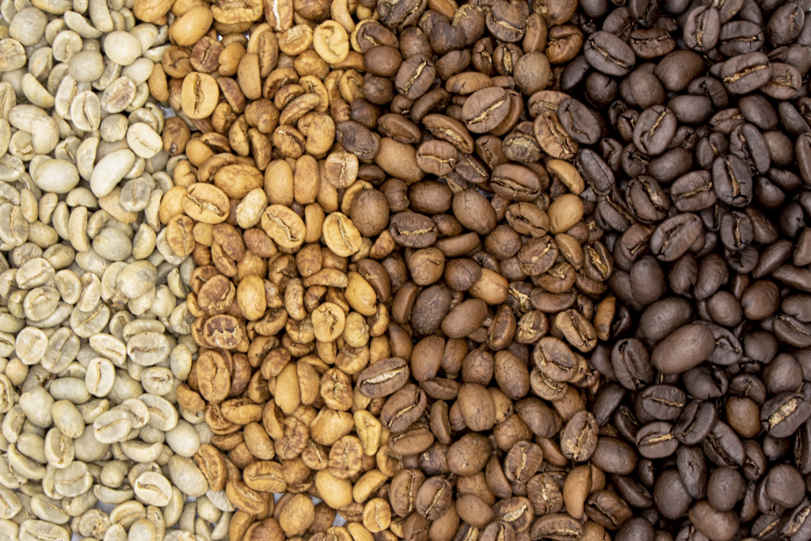

# Introduction

In this research we will concentrate on the coffee ratings data set.

The data comes from Coffee Quality Database courtesy of Buzzfeed Data Scientist James LeDoux.

The original data can be found on James’ github.

This dataset contains a lot of interesting information about Coffee ratings such as: species, country of origin, flavor, etc.

We will focus on:

1. Transforming our dataset.
2. Visualizations.
3. Statistical Models and methods learned during the course.

Our goals is to demonstrate and practice the different methods that we have learned in the course by examining the relationship between the different variables from the coffee ratings dataset.

In addition we would like to find conclusions that can be used by the home user to make his next coffee more tastier.

For example,It is customary to think that moisture affects the quality of coffee, We will examine this field in our analysis.

The methods which we will use in this research are:

1. Hypothesis test.
2. Model of multiple regression
3. Model of simple linear regression

## Part 1 - Importing the data set

The dataset was in an excel file- a convenient format to work with.

lets read this file with read.csv function that imports the data into R

```r
library(tidyverse)
library("ggpubr")
library(janitor)
library(dplyr)
library(ggplot2)
library(ggcorrplot)
library(broom)

coffee_ratings <- readr::read_csv('https://raw.githubusercontent.com/rfordatascience/tidytuesday/master/data/2020/2020-07-07/coffee_ratings.csv')
coffee_ratings
```

```
## # A tibble: 1,339 x 43
##    total_cup_points species owner  country_of_origin farm_name  lot_number mill
##               <dbl> <chr>   <chr>  <chr>             <chr>      <chr>      <chr>
##  1             90.6 Arabica metad~ Ethiopia          "metad pl~ <NA>       meta~
##  2             89.9 Arabica metad~ Ethiopia          "metad pl~ <NA>       meta~
##  3             89.8 Arabica groun~ Guatemala         "san marc~ <NA>       <NA>
##  4             89   Arabica yidne~ Ethiopia          "yidnekac~ <NA>       wole~
##  5             88.8 Arabica metad~ Ethiopia          "metad pl~ <NA>       meta~
##  6             88.8 Arabica ji-ae~ Brazil             <NA>      <NA>       <NA>
##  7             88.8 Arabica hugo ~ Peru               <NA>      <NA>       hvc
##  8             88.7 Arabica ethio~ Ethiopia          "aolme"    <NA>       c.p.~
##  9             88.4 Arabica ethio~ Ethiopia          "aolme"    <NA>       c.p.~
## 10             88.2 Arabica diamo~ Ethiopia          "tulla co~ <NA>       tull~
## # ... with 1,329 more rows, and 36 more variables: ico_number <chr>,
## #   company <chr>, altitude <chr>, region <chr>, producer <chr>,
## #   number_of_bags <dbl>, bag_weight <chr>, in_country_partner <chr>,
## #   harvest_year <chr>, grading_date <chr>, owner_1 <chr>, variety <chr>,
## #   processing_method <chr>, aroma <dbl>, flavor <dbl>, aftertaste <dbl>,
## #   acidity <dbl>, body <dbl>, balance <dbl>, uniformity <dbl>,
## #   clean_cup <dbl>, sweetness <dbl>, cupper_points <dbl>, moisture <dbl>,
## #   category_one_defects <dbl>, quakers <dbl>, color <chr>,
## #   category_two_defects <dbl>, expiration <chr>, certification_body <chr>,
## #   certification_address <chr>, certification_contact <chr>,
## #   unit_of_measurement <chr>, altitude_low_meters <dbl>,
## #   altitude_high_meters <dbl>, altitude_mean_meters <dbl>
```

First, we need to get to know our data set.

For this purpose we will look at our data set briefly, with glimpse() function.

```r
glimpse(coffee_ratings)
```

```
## Rows: 1,339
## Columns: 43
## $ total_cup_points      <dbl> 90.58, 89.92, 89.75, 89.00, 88.83, 88.83, 88.75,~
## $ species               <chr> "Arabica", "Arabica", "Arabica", "Arabica", "Ara~
## $ owner                 <chr> "metad plc", "metad plc", "grounds for health ad~
## $ country_of_origin     <chr> "Ethiopia", "Ethiopia", "Guatemala", "Ethiopia",~
## $ farm_name             <chr> "metad plc", "metad plc", "san marcos barrancas ~
## $ lot_number            <chr> NA, NA, NA, NA, NA, NA, NA, NA, NA, NA, NA, NA, ~
## $ mill                  <chr> "metad plc", "metad plc", NA, "wolensu", "metad ~
## $ ico_number            <chr> "2014/2015", "2014/2015", NA, NA, "2014/2015", N~
## $ company               <chr> "metad agricultural developmet plc", "metad agri~
## $ altitude              <chr> "1950-2200", "1950-2200", "1600 - 1800 m", "1800~
## $ region                <chr> "guji-hambela", "guji-hambela", NA, "oromia", "g~
## $ producer              <chr> "METAD PLC", "METAD PLC", NA, "Yidnekachew Dabes~
## $ number_of_bags        <dbl> 300, 300, 5, 320, 300, 100, 100, 300, 300, 50, 3~
```

[output cut: 30 more lines]

## Part 2 - Transformation & Cleaning

First of all, we chose the variables that would interest us for further analysis:

1. Total cup points
2. Species
3. Country of origin
4. Altitude mean meters
5. Processing method
6. Moisture
7. Aroma
8. Flavor
9. Body

10.Balance

- We deleted all the lines that contain NA (there is enough information so there is no problem to do so).
- Once we examined the data we discovered a few things:
  1. Some samples appear to be completely dry from their Moisture values, which seems a bit odd as the majority of samples are not dry. That is why we will remove all those samples.
  2. In the mean altitude variable there are extreme values. That is why we will remove them as well.

The updated data attached:

```r
data<-coffee_ratings%>%
  select(total_cup_points,species,country_of_origin,altitude_mean_meters,processing_method,moisture,aroma,flavor,body,balance)%>%
  filter(moisture>0,altitude_mean_meters>100,altitude_mean_meters<3600)%>%
  drop_na()
glimpse(data)
```

```
## Rows: 836
## Columns: 10
## $ total_cup_points     <dbl> 90.58, 89.92, 89.00, 88.83, 88.25, 88.08, 87.25, ~
## $ species              <chr> "Arabica", "Arabica", "Arabica", "Arabica", "Arab~
## $ country_of_origin    <chr> "Ethiopia", "Ethiopia", "Ethiopia", "Ethiopia", "~
## $ altitude_mean_meters <dbl> 2075.00, 2075.00, 2000.00, 2075.00, 1822.50, 1905~
## $ processing_method    <chr> "Washed / Wet", "Washed / Wet", "Natural / Dry", ~
## $ moisture             <dbl> 0.12, 0.12, 0.11, 0.12, 0.10, 0.10, 0.10, 0.11, 0~
## $ aroma                <dbl> 8.67, 8.75, 8.17, 8.25, 8.08, 8.17, 8.42, 8.08, 8~
## $ flavor               <dbl> 8.83, 8.67, 8.58, 8.50, 8.58, 8.67, 8.25, 8.25, 8~
## $ body                 <dbl> 8.50, 8.42, 8.50, 8.42, 7.67, 7.75, 7.92, 8.00, 7~
## $ balance              <dbl> 8.42, 8.42, 8.25, 8.33, 8.42, 8.17, 8.00, 8.33, 8~
```

We now have 836 rows out of 1339 rows, this is enough for our further analysis.

## Part 3 - Visualizations

In this part we will examine our data through different graphs and plot with ggplot2 package.

#### The distributions of different variables:

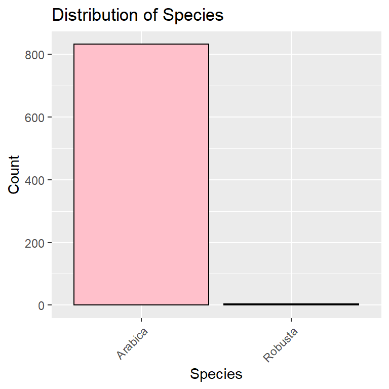

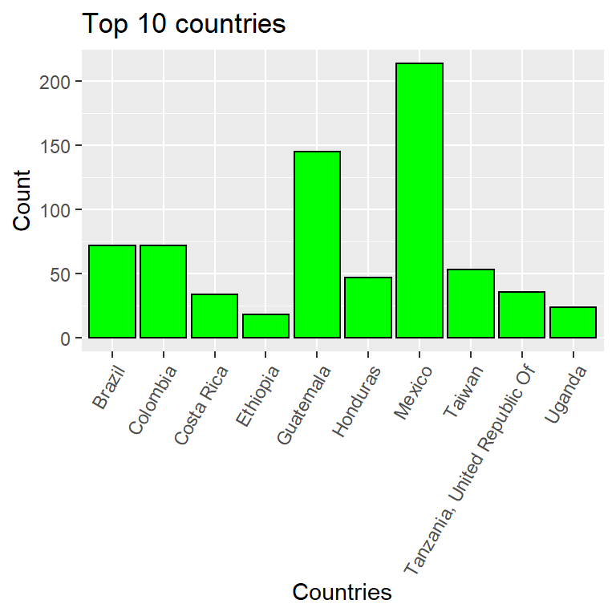

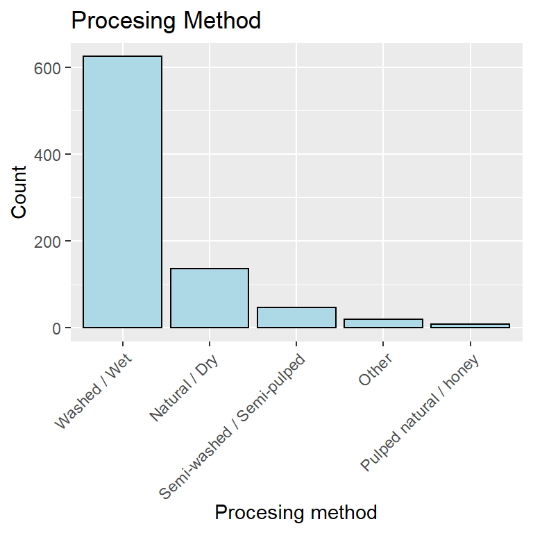

#### The density of different variables:

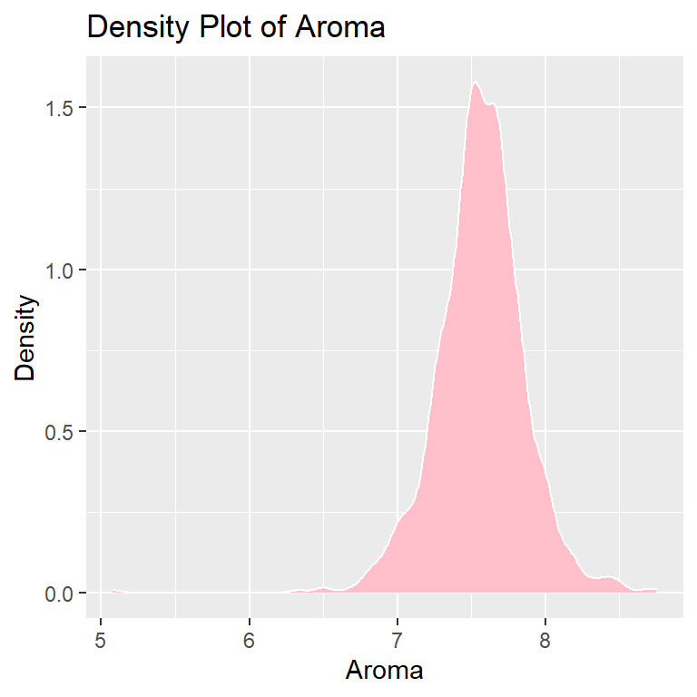

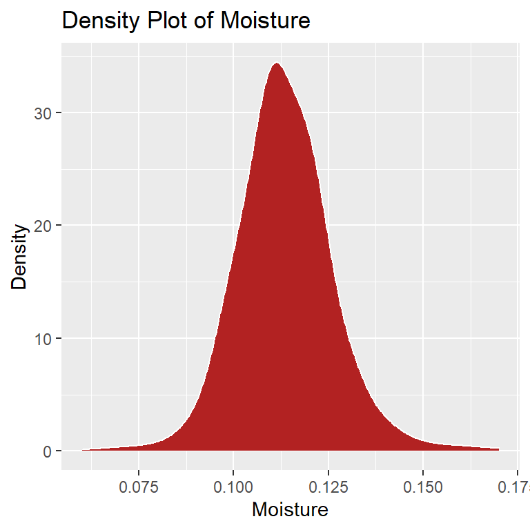

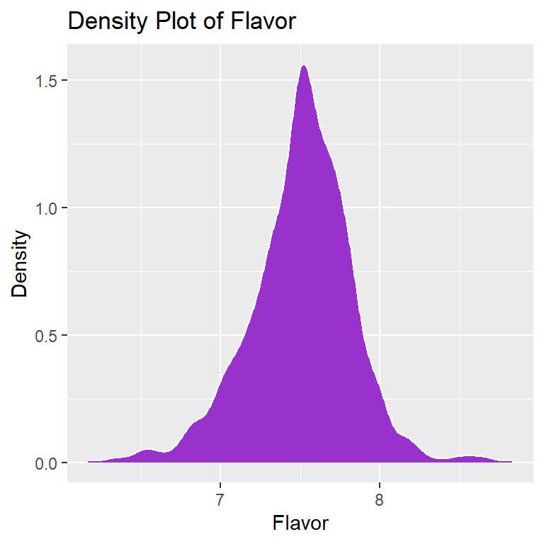

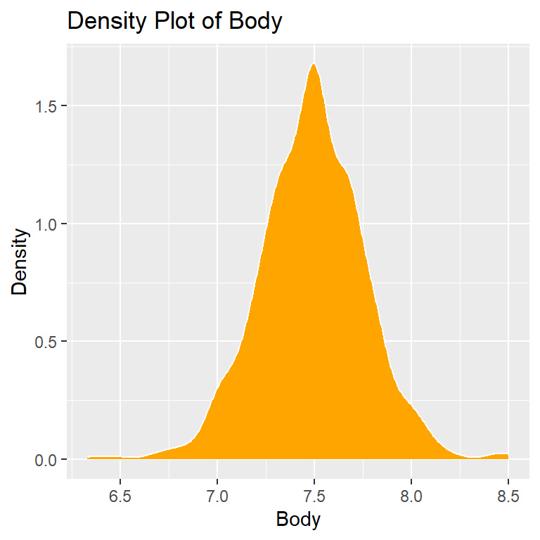

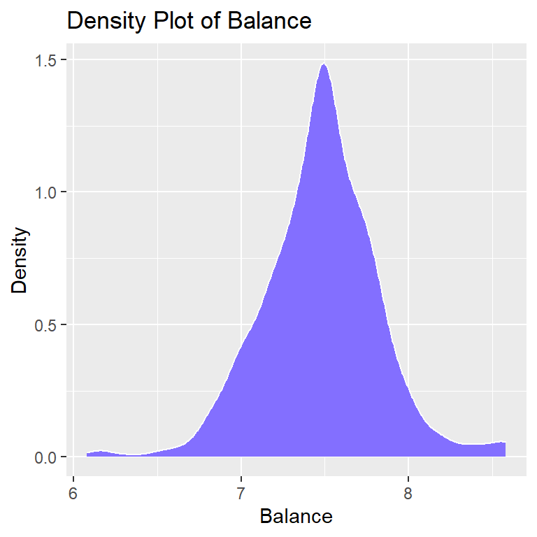

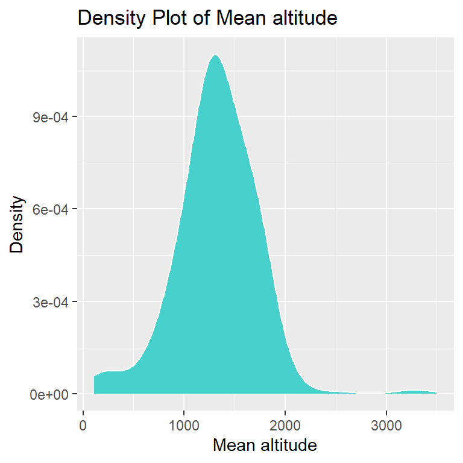

From the output variables, we can see that:

1. a very small number of Robusta beans have been graded
2. Coffee is mainly grown between 700 and 2000 m
3. Most of the samples have been processed using the Washed / Wet method and the remainder are mostly Natural / Dry.
4. Aroma, Flavor, Body, Balance are similarly distributed with mean values around 7.5 and approximate range of 6.5-8.5
5. Moisture is distributed with mean value of 0.113 and approximate range of 0.08-0.14.

## Part 4 - Modeling

#### First Model - T-test:

We would like to check if the coffee in Colombia is better than in Brazil.

The null hypothesis is that the two means are equal, and the alternative is that one sample is larger than the other.

Colombia and Brazil have the same number of samples so the test will be more reliable.

To perform two-samples t-test comparing the means of two independent samples (x & y), the R function t.test() can be used as follow:

##### H0:μColombia−μBrazil=0

##### H1:μColombia−μBrazil>0

```r
mean_Bra<-data%>%filter(country_of_origin=='Brazil')%>%
  select(total_cup_points)
mean_Col<-data%>%filter(country_of_origin=='Colombia')%>%
  select(total_cup_points)

t.test(mean_Col,mean_Bra,alternative = "greater",conf.level = 0.95)
```

```
##
##  Welch Two Sample t-test
##
## data:  mean_Col and mean_Bra
## t = 3.8469, df = 116.83, p-value = 9.768e-05
## alternative hypothesis: true difference in means is greater than 0
## 95 percent confidence interval:
##  0.4249388       Inf
## sample estimates:
## mean of x mean of y
##  83.46889  82.72208
```

##### What we have discovered from the test:

The p-value of t-test is p = 0.00009768. Its lower than the significance level alpha = 0.05.

In conclusion, it can be assumed that coffee in Colombia is better than coffee in Brazil, at a 95 percent certainty level.

We can also support this due to the confidence interval which results here.

#### Second Model - Multiple regression & Simple linear regression:

A Multiple linear regression is now done on the parameters of flavor,body, moisture, balance and aroma.

In order to test the effect of each variable on the coffee rating We will use multiple linear regression model and represent it by the summery table.

```r
model<-lm(total_cup_points~aroma+moisture+balance+body+flavor,data)
summary(model)
```

```
##
## Call:
## lm(formula = total_cup_points ~ aroma + moisture + balance +
##     body + flavor, data = data)
##
## Residuals:
##      Min       1Q   Median       3Q      Max
## -16.3764  -0.1725   0.2491   0.5690   2.2503
##
## Coefficients:
##             Estimate Std. Error t value Pr(>|t|)
## (Intercept)  21.7658     1.4992  14.518  < 2e-16 ***
## aroma         0.6924     0.2234   3.099  0.00201 **
## moisture      5.6170     3.8064   1.476  0.14042
## balance       2.6287     0.2205  11.924  < 2e-16 ***
## body          0.4373     0.2543   1.719  0.08592 .
## flavor        4.1900     0.2658  15.761  < 2e-16 ***
## ---
## Signif. codes:  0 '***' 0.001 '**' 0.01 '*' 0.05 '.' 0.1 ' ' 1
##
## Residual standard error: 1.3 on 830 degrees of freedom
## Multiple R-squared:  0.7715, Adjusted R-squared:  0.7701
## F-statistic: 560.5 on 5 and 830 DF,  p-value: < 2.2e-16
```

What we have discovered from the test:

Based on the data in the table we can see that the most influential variable on the coffee rating is flavor.

When it goes up by one unit the coffee rating goes up by more then 4 units.

What is very interesting about this table is that the moisture is not significant, therefore it is not possible to say with a level of certainty of 95% that there is a linear relationship between moisture and the coffee rating.

We understand this is probably happening because all the samples are at a standard moisture level.

We will now examine a correlation between the variables:

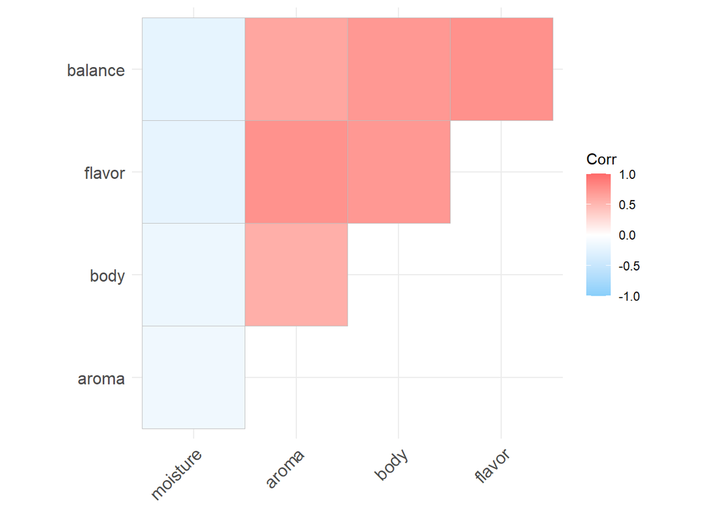

```r
selected_variable <- data %>%select(moisture,aroma,flavor,body,balance)
cor_variable <- cor(selected_variable)
ggcorrplot(cor_variable, type = "upper", hc.order = T, hc.method = "complete",
           colors = c("lightskyblue","white","indianred1"))
```

We can see that there is a correlation between all our significant variables. Therefore, we understand that the variables affects each other, and we can not conclude unequivocally that only one variable affects the overall coffee rating.

Lets check the VIF:

```r
car::vif(model)
```

```
##    aroma moisture  balance     body   flavor
## 2.309401 1.064646 2.841831 2.351653 3.757900
```

We can see that the VIF is less than 5 in all of our variables, Therefore, according to what we have learned in the course, Despite the multicolinearity we can keep all our variables.

We will select the flavor variable, which has the strongest effect (b1 of 4.1) and test it for homoscedasticity.

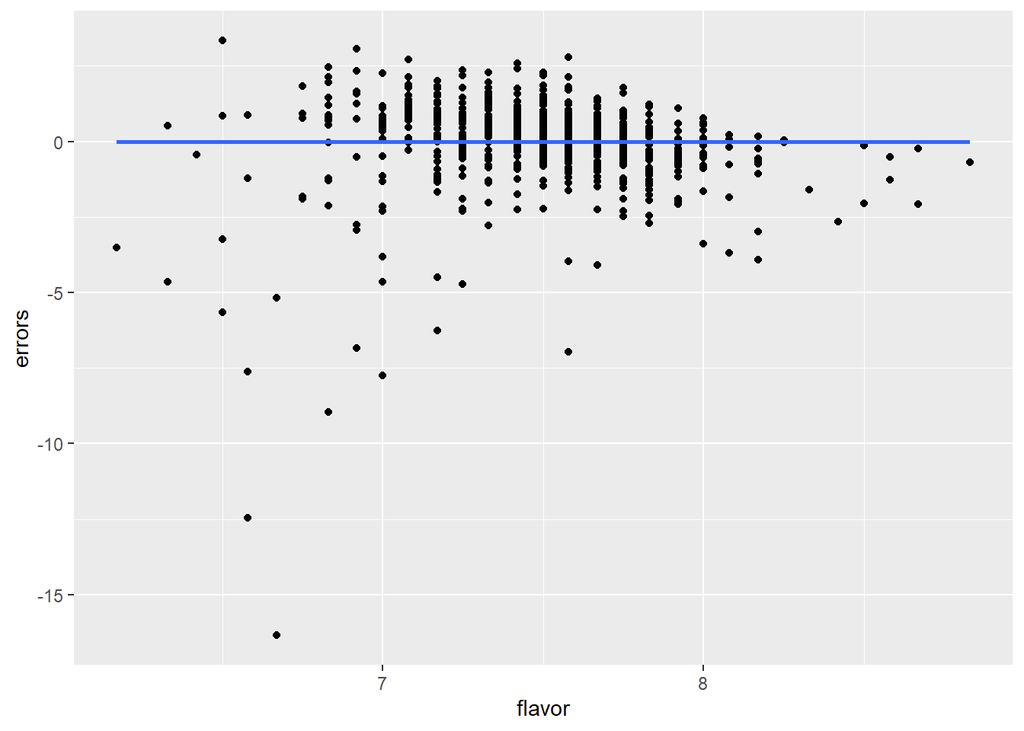

```r
model<-lm(total_cup_points~flavor,data)
model.diag.metrics <- augment(model)
errors<-model$residuals
ggplot(model.diag.metrics, aes(flavor, errors)) +
  geom_point() +
  stat_smooth(method = lm, se = FALSE) +
  geom_segment(aes(xend = flavor, yend = errors))
```

Refered to the graph attached above, we can see that the variance of the error is not constant around the X-axis. Therefore, there is no homoscedasticity.

Despite the lack of homoscedasticity, we will continue with the data analysis and present the linear relationship between flavor and coffee rating.

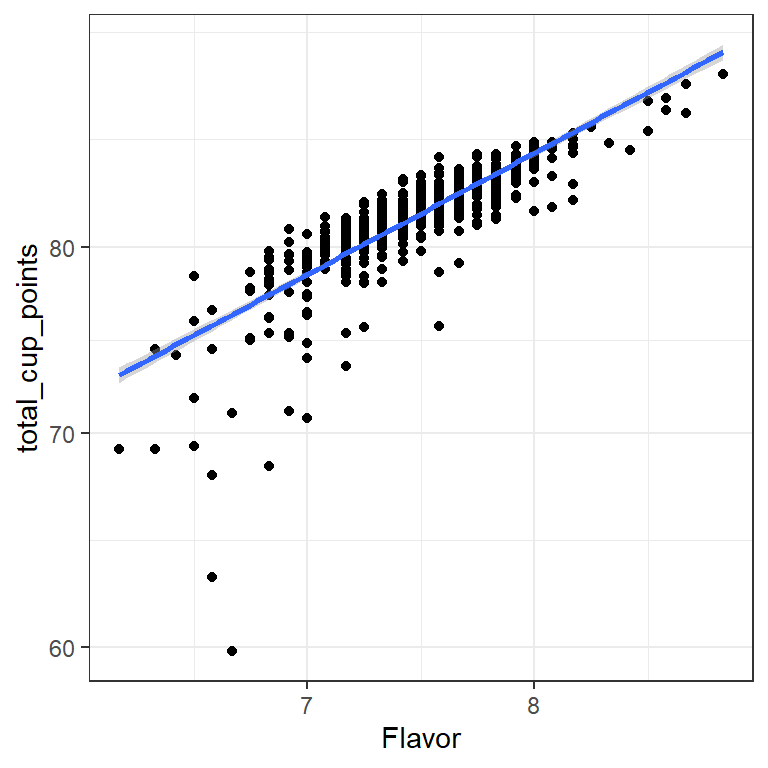

```
##
## Call:
## lm(formula = total_cup_points ~ flavor, data = data)
##
## Residuals:
##      Min       1Q   Median       3Q      Max
## -16.3477  -0.3906   0.1691   0.7134   3.3395
##
## Coefficients:
##             Estimate Std. Error t value Pr(>|t|)
## (Intercept)  29.5999     1.1503   25.73   <2e-16 ***
## flavor        6.9832     0.1531   45.61   <2e-16 ***
## ---
## Signif. codes:  0 '***' 0.001 '**' 0.01 '*' 0.05 '.' 0.1 ' ' 1
##
## Residual standard error: 1.451 on 834 degrees of freedom
## Multiple R-squared:  0.7138, Adjusted R-squared:  0.7135
## F-statistic:  2080 on 1 and 834 DF,  p-value: < 2.2e-16
```

Therefore it can be concluded at a 95 percent significance level that there is a strong linear relationship between flavor and total cup point.

## Part 5 - Conclusion:

We tried to find useful conclusions for the home consumer, so we examined 2 main questions:

1. Is Colombian coffee better than Brazilian coffee?
2. We looked for a relationship between variables and the coffee rating, in order to recommend to the home user a variable that he should pay attention to, in order to get better coffee.

##### Conclusions:

1. Based on the analyzed data, the coffee produced in Colombia is better than the coffee produced in Brazil.

   So, in case someone is thinking whether to buy Colombian coffee or Brazilian coffee, we recommend going for the Colombian.
2. First, before we looked at the data, we assumed that moisture is a very significant factor influencing the coffee rating.

   We were surprised to find that according to the data, this claim is not true.

   We assume this happened because all the samples were taken right after the coffee package was opened, so the moisture has not changed to values that can affect the results.

   In addition, we showed that flavor is the most significant factor in coffee ranking, and also presented the correlation between all the significant variables.

We hope these conclusions will help you make your next coffee alot better.

#Some coffee + Some thinking = Great ideas!